# Временные ряды 3.

#### 2. Подберите параметры модели SARIMAX для этого ряда.

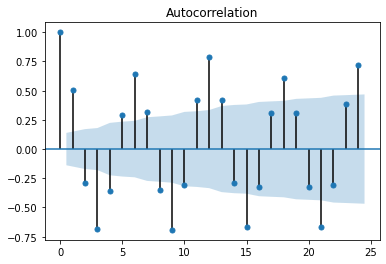

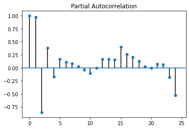

```python
sm.graphics.tsa.plot_acf(data_m['PJME_MW'], lags=12*2)
plt.show()
sm.graphics.tsa.plot_pacf(data['PJME_MW'], lags=12*2)
plt.show()
```

```python
# нет разности
sm.tsa.stattools.adfuller(data_m['PJME_MW'], regression='ct')
```

```
(-2.6305818240369043,
 0.26601840067282456,
 15,
 184,
 {'1%': -4.008832839770228,
  '5%': -3.434625048376243,
  '10%': -3.141221698677776},
 3230.0620591439747)
```

```python
# первая разность
sm.tsa.stattools.adfuller(data_m['PJME_MW'].diff(1)[1:], regression='ct')
```

```
(-6.055831211690867,
 1.6754622441799428e-06,
 14,
 184,
 {'1%': -4.008832839770228,
  '5%': -3.434625048376243,
  '10%': -3.141221698677776},
 3217.557676725865)
```

```python
# вторая разность
sm.tsa.stattools.adfuller(data_m['PJME_MW'].diff(1).diff(1)[2:], regression='ct')
```

```
(-7.846327761738741,
 1.6190898890526661e-10,
 15,
 182,
 {'1%': -4.009392790586421,
  '5%': -3.434893396561173,
  '10%': -3.141378799874199},
 3228.597432681512)
```

Видим что брать $d$ больше 2 нет смысла. Используем сеточный выбор для подбора оптимальных параметров модели SARIMA. Качество модели оцениваем по критерию Акаике (AIC). Чем он меньше, тем лучше.

```python
# Коэффициенты модели ARIMA p, d и q в диапазоне 0-2
p = d = q = range(0, 3)
pdq = list(itertools.product(p, d, q))

# Коэффициенты модели S p, d, q в диапазоне 0-2
pdq_seasonal = list(itertools.product(p, d, q, [12]))
```

```python
warnings.filterwarnings("ignore")

coefs = []
for param in pdq:
    for param_seasonal in pdq_seasonal:
        model = sm.tsa.statespace.SARIMAX(
           data_m['PJME_MW'].values[:-30],
           order=param,
           seasonal_order=param_seasonal,
           enforce_stationarity=False,
           enforce_invertibility=False
        )

        results = model.fit()
        coefs.append((param, param_seasonal, results.aic))
```

```python
coefs.sort(key=lambda tup: tup[2])
coefs[:20]
```

```
[((2, 2, 2), (0, 2, 2, 12), 2098.6836036627046),
 ((0, 2, 2), (1, 2, 2, 12), 2112.443245948766),
 ((0, 2, 2), (0, 2, 2, 12), 2113.1777286090473),
 ((1, 1, 2), (1, 2, 2, 12), 2114.7577503601137),
 ((0, 1, 2), (0, 2, 2, 12), 2117.4733363087985),
 ((0, 1, 2), (1, 2, 2, 12), 2118.767003298697),
 ((0, 1, 2), (2, 2, 2, 12), 2120.4887322477393),
 ((2, 1, 2), (2, 2, 2, 12), 2121.2093942771453),
 ((2, 1, 2), (0, 2, 2, 12), 2123.5220660500763),
 ((1, 1, 2), (2, 2, 2, 12), 2128.10813160638),
 ((1, 1, 1), (0, 2, 2, 12), 2129.3504082887057),
 ((1, 1, 1), (1, 2, 2, 12), 2131.119001423513),
 ((1, 1, 2), (0, 2, 2, 12), 2131.282765453389),
 ((1, 1, 1), (2, 2, 2, 12), 2132.3148580555717),
 ((2, 1, 1), (1, 2, 2, 12), 2132.6621472690354),
 ((0, 2, 2), (2, 2, 2, 12), 2133.2881224296216),
 ((2, 1, 1), (2, 2, 2, 12), 2134.449159480929),
 ((2, 2, 2), (1, 2, 2, 12), 2138.085182104991),
 ((2, 1, 1), (2, 2, 1, 12), 2139.169629700019),
 ((0, 1, 1), (2, 2, 2, 12), 2140.1676788892687)]
```

Наилучшие результаты показала модель c коэффициентаvb $p=2, d=2, q=2$ и коэффициентах сезонности $p=0, d=2, q=2, s=12$. Но для дальнейшего анализа выберем модель с параметрами $p=0, d=2, q=2$ и коэффициентами сезонности $p=0, d=2, q=2, s=12$ Критерий Акаике составил $AIC=2113$. Рассмотрим результаты этой модели более детально.

```python
param = [0, 2, 2]
param_seasonal = [0, 2, 2, 12]
N_test = 30

model = sm.tsa.statespace.SARIMAX(
    data_m['PJME_MW'].values[:-N_test],
    order=param,
    seasonal_order=param_seasonal,
    enforce_stationarity=False,
    enforce_invertibility=False
)

results = model.fit()
```

```python
print(results.summary().tables[0],results.summary().tables[1])
```

```
                                     SARIMAX Results
==========================================================================================
Dep. Variable:                                  y   No. Observations:                  170
Model:             SARIMAX(0, 2, 2)x(0, 2, 2, 12)   Log Likelihood               -1051.589
Date:                            Fri, 14 Aug 2020   AIC                           2113.178
Time:                                    00:08:34   BIC                           2126.989
Sample:                                         0   HQIC                          2118.785
                                            - 170
Covariance Type:                              opg
========================================================================================== ==============================================================================
                 coef    std err          z      P>|z|      [0.025      0.975]
------------------------------------------------------------------------------
ma.L1         -2.3035      0.082    -27.927      0.000      -2.465      -2.142
ma.L2          1.3119      0.107     12.214      0.000       1.101       1.522
ma.S.L12      -1.5430      0.177     -8.741      0.000      -1.889      -1.197
ma.S.L24       0.5682      0.105      5.390      0.000       0.362       0.775
sigma2      1.424e+06   3.48e+05      4.096      0.000    7.43e+05    2.11e+06
==============================================================================
```

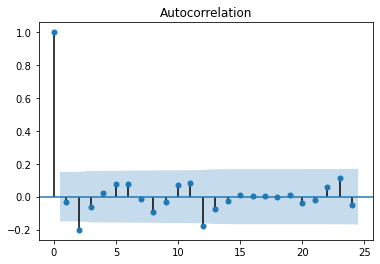

```python
sm.graphics.tsa.plot_acf(results.resid, lags=12*2)
plt.show()
```

Оценим близость распределений остатков модели к нормальному закону, используя визуализацию plot_diagnostics.

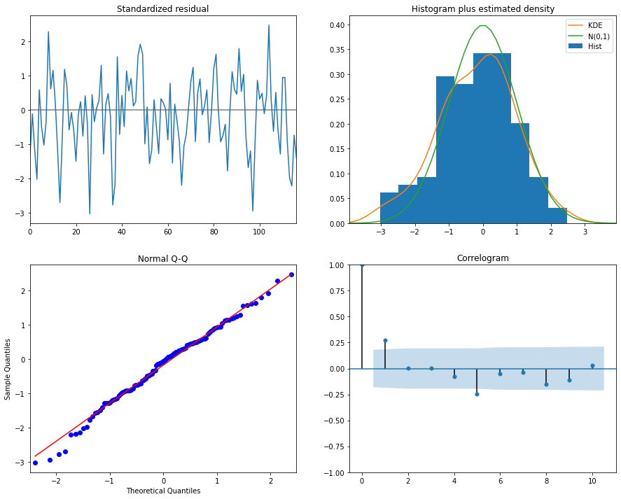

```python
results.plot_diagnostics(figsize=(15, 12))
plt.show()
```

Эти графики показывают то, что выбранная модель подходит для анализа и прогнозирования временного ряда (остатки нормально распределены).

```python
N_pure_predict = 30 # число точек предсказания за границами выборки
N_forecast = N_test + N_pure_predict # общее число точек для предсказания
N_offset = 100 # отступ от начала данных для более удобной визуализации
```

```python
predict_ = results.get_prediction(end=results.nobs + N_forecast)  # делаем предсказание
```

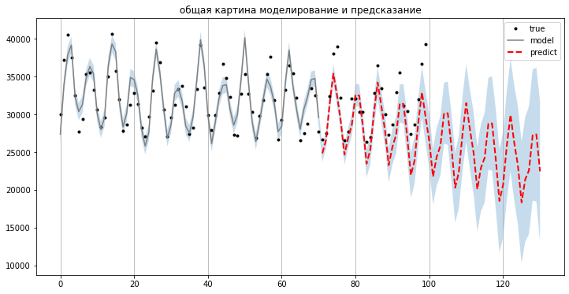

```python
idx = np.arange(len(predict_.predicted_mean) - N_offset)
predict_ci = predict_.conf_int(alpha=0.5)

fig, ax = plt.subplots(figsize=(12,6))
ax.xaxis.grid()
ax.plot(data_m['PJME_MW'].values[N_offset:], 'k.',label='true')

ax.plot(idx[:-N_forecast], predict_.predicted_mean[N_offset:-N_forecast], 'gray', label = 'model')
ax.plot(idx[-N_forecast:], predict_.predicted_mean[-N_forecast:], 'r--', linestyle='--', linewidth=2, label='predict')
ax.fill_between(idx, predict_ci[N_offset:, 0], predict_ci[N_offset:, 1], alpha=0.25)
plt.legend()
ax.set(title='общая картина моделирование и предсказание');
```

#### 3. Сделайте вывод о том, как изменилась модель по сравнению с недельной.

Распределение остатков у модели с месячным ресэмплингом и с недельным ресэмплингом одинаково близки к нормальному распределению. Недельная модель так же плохо предсказывала пиковые значения на тренировочной выборке, однако при прогнозировании 12-и значений все они лежали в доверительном интервале 95%. Предсказания при недельном ресэмлинге более точные чем при месячном.

#### 4. Возмите вариант 1 или 2

```
- Вариант 1) - Постройте ACF, PACF и модель ARIMA для BRENT (недельный ресемплинг)
- Вариант 2) - Постройте ACF, PACF и модель ARIMA для СOVID_19  (по любой стране кроме Китая на дневных графиках )
```

Возьмем 1 вариант.

```python
path2 = '/Users/o.gubanikhin/Downloads/Learn/Машинное обучение в бизнесе/Урок 3. Кейс 1. Работа с признаками и селекция/my_BRENT2019.csv'
brent = pd.read_csv(path2, sep = ',', index_col=[0], parse_dates=[0], usecols=['Дата','Значение'])
brent.tail()
```

| Дата | Значение |
| --- | --- |
| 2019-08-27 | 59.59 |
| 2019-08-28 | 59.84 |
| 2019-08-29 | 60.37 |
| 2019-08-30 | 59.19 |
| 2019-09-01 | 58.84 |

```python
brent_week = brent.resample('W').mean().sort_index()
brent_week.head()
```

| Дата | Значение |
| --- | --- |
| 2010-09-05 | 76.616000 |
| 2010-09-12 | 77.673333 |
| 2010-09-19 | 78.693333 |
| 2010-09-26 | 78.518333 |
| 2010-10-03 | 81.211667 |

```python
brent_week.info()
```

```
<class 'pandas.core.frame.DataFrame'>
DatetimeIndex: 470 entries, 2010-09-05 to 2019-09-01
Freq: W-SUN
Data columns (total 1 columns):
 #   Column    Non-Null Count  Dtype
---  ------    --------------  -----
 0   Значение  469 non-null    float64
dtypes: float64(1)
memory usage: 7.3 KB
```

```python
# Убедимся, что в индексах нет дублей
brent_week[brent_week.index.duplicated(keep=False)].size
```

```
0
```

```python
# Убедимся, что нет пропущенных индексов
pd.date_range('2010-09-05', '2019-09-01', freq="W").size == brent_week.index.size
```

```
True
```

```python
# Убедимся, что в данных нет пропусков
brent_week[brent_week['Значение'].isna()]
```

| Дата | Значение |
| --- | --- |
| 2011-10-16 | NaN |

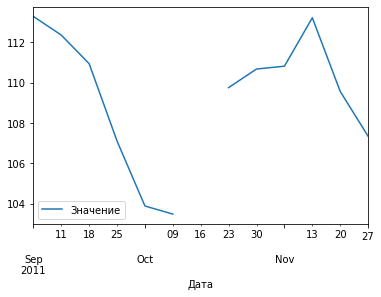

```python
brent_week['2011-09-01':'2011-12-01'].plot()
plt.show()
```

Одно значение пропущено. Заполним.

```python
one_week = timedelta(weeks=1)
dropped_indexes = brent_week[brent_week['Значение'].isna()].index
dropped_values = []

for index in dropped_indexes:
    prev = brent_week.iloc[brent_week.index == index - one_week]['Значение'].values[0]
    next = brent_week.iloc[brent_week.index == index + one_week]['Значение'].values[0]
    curr = (prev + next) / 2
    dropped_values.append(curr)
```

```python
df = pd.DataFrame(dropped_values, index=dropped_indexes, columns=["Значение"])
df
```

| Дата | Значение |
| --- | --- |
| 2011-10-16 | 106.616667 |

```python
brent_week = brent_week.dropna().append(df, sort=False).sort_index()
```

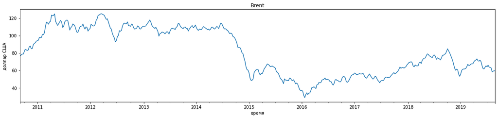

```python
brent_week['Значение'].plot(style='-', figsize=(20,4))
plt.title('Brent')
plt.ylabel('доллар США')
plt.xlabel('время')
plt.show()
```

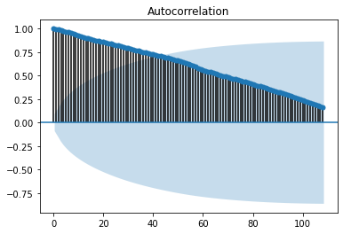

```python
sm.graphics.tsa.plot_acf(brent_week['Значение'], lags=54*2)
plt.show()
```

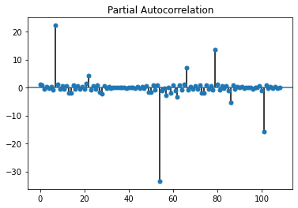

```python
sm.graphics.tsa.plot_pacf(brent_week['Значение'], lags=54*2)
plt.show()
```

```python
# нет разности
sm.tsa.stattools.adfuller(brent_week['Значение'], regression='ct')
```

```
(-2.3008705058688363,
 0.43346844670846224,
 5,
 464,
 {'1%': -3.978414375776397,
  '5%': -3.419994493296638,
  '10%': -3.1326408685380063},
 1961.4565582681169)
```

```python
# первая разность
sm.tsa.stattools.adfuller(brent_week['Значение'].diff(1)[1:], regression='ct')
```

```
(-7.865467885113204,
 1.462281199852931e-10,
 4,
 464,
 {'1%': -3.978414375776397,
  '5%': -3.419994493296638,
  '10%': -3.1326408685380063},
 1958.9911453986865)
```

```python
# вторая разность
sm.tsa.stattools.adfuller(brent_week['Значение'].diff(1).diff(1)[2:], regression='ct')
```

```
(-8.968132109925236,
 4.2846118702378404e-13,
 16,
 451,
 {'1%': -3.9789846182231026,
  '5%': -3.420269730716854,
  '10%': -3.1328025785176075},
 1988.8364147898048)
```

```python
# Коэффициенты модели ARIMA p, d и q
p = d = q = range(0, 3)
pdq = list(itertools.product(p, d, q))
```

```python
warnings.filterwarnings("ignore")

N = 30

coefs = []
for param in pdq:
    try:
        model = ARIMA(
            brent_week['Значение'].values[:-N],
            order=param,
        )

        results = model.fit()
        coefs.append((param, results.aic))
    except:
        continue
```

```python
coefs.sort(key=lambda tup: tup[1])
coefs[:5]
```

```
[((0, 1, 1), 1912.636217965228),
 ((1, 1, 1), 1914.384044506549),
 ((0, 1, 2), 1914.4206900437111),
 ((1, 1, 2), 1915.0128869244804),
 ((2, 1, 0), 1915.2093589717017)]
```

Наилучшие показатели у $p=0$, $d=1$, $q=1$.

```python
param = [0, 1, 1]
model = ARIMA(
    brent_week['Значение'].values[:-N],
    order=param,
)

results = model.fit()
```

#### 5. Оцените результат моделирования

```python
print(results.summary().tables[0],results.summary().tables[1])
```

```
                             ARIMA Model Results
==============================================================================
Dep. Variable:                    D.y   No. Observations:                  439
Model:                 ARIMA(0, 1, 1)   Log Likelihood                -953.318
Method:                       css-mle   S.D. of innovations              2.122
Date:                Fri, 14 Aug 2020   AIC                           1912.636
Time:                        23:11:47   BIC                           1924.890
Sample:                             1   HQIC                          1917.471

============================================================================== ==============================================================================
                 coef    std err          z      P>|z|      [0.025      0.975]
------------------------------------------------------------------------------
const         -0.0337      0.138     -0.243      0.808      -0.305       0.238
ma.L1.D.y      0.3673      0.044      8.333      0.000       0.281       0.454
==============================================================================
```

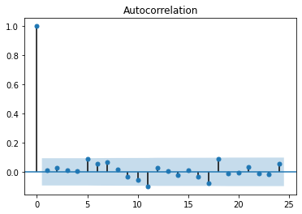

```python
sm.graphics.tsa.plot_acf(results.resid, lags=24)
plt.show()
```

```python
sm.tsa.stattools.adfuller(results.resid)
```

```
(-20.705628106588716,
 0.0,
 0,
 438,
 {'1%': -3.445368352170937,
  '5%': -2.8681614049724002,
  '10%': -2.570296970872167},
 1832.3694571115184)
```

ADF показывает, что остатки являются стационарным рядом. Сделаем прогноз.

```python
y_p = results.predict(len(brent_week[:-N]), len(brent_week[:-N]), typ='levels')
y_f = results.forecast(N)
```

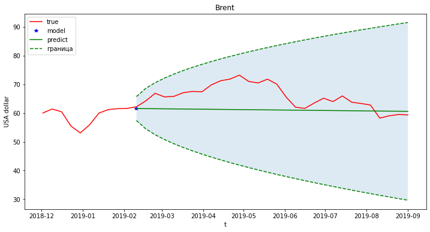

```python
fig, ax = plt.subplots(figsize=(12,6))

plt.plot(brent_week[-10-N:], 'r', label ='true')
plt.plot(brent_week.index[-N], y_p, '*b', label ='model')

plt.plot(brent_week.index[-N:], y_f[0], 'g', label ='predict')
plt.plot(brent_week.index[-N:], y_f[2][:,1], '--g', label = 'граница')
plt.plot(brent_week.index[-N:], y_f[2][:,0], '--g')

ax.fill_between(brent_week.index[-N:],  y_f[2][:,1], y_f[2][:,0], alpha=0.15)

plt.title('Brent')
plt.ylabel('USA dollar')
plt.xlabel('t')

plt.legend()
plt.show()
```

Фактические значения лежат в доверительном интервале спрогнозированных значений. Модель хорошо предсказывает данные. Но этот доверительный интервал очень большой, так что ценность данной модели низкая.

#### 6. Сделайте предположение о моделях, которые лучше работают с техниками регрессии на основе AR I MA.